# Evans et al 2005

Simulation ideas based on relevant mechanisms from Evans et al 2005

Tim Szewczyk

2017 May 3

# Mechanisms

There are nine broad mechanisms laid out in Evans et al 2005. Chunks of the manuscript text are pasted below for each hypothesis to give an overview and describe the main predictions, followed by some code for simulation possibilities.

## Sampling

#### Summary

Increased productive energy elevates the number of individuals that a locality can support. Assemblages are comprised of individuals randomly selected from a regional species pool; in high energy areas, more individuals are selected, increasing the number of novel species that are added to an assemblage.

**NPP –> abundance –> larger samples –> more species**

#### Text

Total abundance of an assemblage is probably limited by productive energy availability (Hairston, Smith&Slobodkin, 1960). The thermoregulatory load theory (Turner et al., 1988) suggests that solar energy limits the number of endotherms in an assemblage by altering how much energy individuals can invest in reproduction, rather than thermoregulation. Increasing energy availability may thus result in higher total abundance. The sampling mechanism is one of two through which increased energy availability may generate positive correlations between total abundance and species richness.

If an assemblage does not contain all the species that occur in its regional species pool then the probability that an individual selected randomly from the regional species pool will represent a novel species is greater than zero. If an assemblage is comprised of randomly selected individuals from a regional species pool its species richness will thus increase as increased energy availability increases total abundance (Fig. 1; Gotelli & Graves, 1996). This sampling mechanism is analogous to one pathway postulated to contribute to species-area relationships (Connor & McCoy, 1979; Moore & Keddy, 1989; Storch, Sizling & Gaston, 2003).

#### Scale and taxonomy

Increasing grain size elevates species richness, as described by the species-area relationship. The difference in species richness between an assemblage and its regional species pool will thus decrease as spatial grain increases, leading to a reduced probability that randomly selected individuals will constitute novel species. As spatial extent increases, assemblages are more likely to be derived from different regional species pools, of varying size, which may mask any simple relationship between the number of individuals selected and species richness. Therefore, even if assemblages are random samples from larger species pools the sampling mechanism is unlikely to contribute significantly to positive species–energy relationships at the extreme macro-scale. Its applicability is, however, unlikely to differ systematically between taxonomic groups.

#### Predictions

Assuming that species in the regional species pool are not equally abundant, increasing the number of individuals in an assemblage will add common species more rapidly than rare ones. Consequently, species richness should be a positive decelerating function of total abundance and energy availability. Such patterns may arise through other mechanisms, particularly the increased population size mechanism (see section III.2). The sampling mechanism’s diagnostic prediction is thus that the form of these relationships is identical to those predicted by random sampling.

This can be tested in two ways. First, methods such as jack-knifing can be used to estimate species richness if subsampling was complete, thus removing any influence of the sampling effect (Colwell & Coddington, 1994). If these estimates of species richness do not exhibit a positive and decelerating relationship with abundance/energy, which is present in the original data, then support is provided for the sampling mechanism (Kaspari et al., 2003). Second, when species richness and abundance are recorded at two or more grain sizes, the species-abundance/energy distribution at the larger grain can be randomly sampled to generate the species richness predicted, by the sampling mechanism, at the smaller spatial grain – which can then be compared with real data (Gotelli & Graves, 1996; Kaspari et al., 2003).

The sampling mechanism predicts that, within a region, spatial turnover in species richness, $\beta$ diversity, will not differ from that generated by simulated random draws of individuals from the regional species pool. As species are drawn from the same species pool, b diversity is expected to be low and, more diagnostically, the random nature of this process should generate b diversity values that are uncorrelated with the distance between sampling points.

The sampling mechanism may, by chance, generate patterns that aremore likely to arise from other mechanisms. In particular, an individual that is randomly selected from a regional species pool is more likely to be one that is common in that pool. If assemblages are constructed by random draws, rare species may thus only occur in the high-energy assemblages that comprise a large number of individuals, giving rise to nested species distributions.

#### Summary

The sampling mechanism offers a plausible explanation for species–energy relationships, but has received inadequate testing. Circumstantial evidence, the form of correlations between richness, energy and abundance, suggests that the mechanism may frequently, but not invariably, contribute to species–energy relationships. The one sufficient complete test supports this (Kaspari, Yuan & Alonso, 2003), but along with theoretical considerations and data on $\beta$ diversity suggests that it is unlikely to contribute significantly to macro-scale species–energy relationships.

```r
# Straight forward I think:
# - nSpp constant
# - K.comm ~ NPP
# - model each species
# - sample - certain percentage?

## Set model parameters
nSim <- 2000
tMax <- 20
nSpp.r <- 50  # regional species pool
NPP <- seq(10, 200, by=10)
NPP.b <-100
K.avg <- 100
K.comm <- NPP*NPP.b + nSpp.r*K.avg  # Built-in effect of NPP on K.comm
smp.p <- 0.5

## Set population growth parameters
r.min <- 0.5  # min possible avg growth rate
r.max <- 1.1  # max possible avg growth rate
r <- runif(nSpp.r, min=r.min, max=r.max)  # avg growth rate for each species
s2.min <- 0.01  # min possible species stochasticity
s2.max <- 2  # max possible species stochasticity
sd <- sqrt(runif(nSpp.r, min=s2.min, max=s2.max))  # sd of r for each species

comm.ls <- vector("list", length(K.comm))
samp.ls <- comm.ls
for(j in 1:length(K.comm)) {
  # set regional parameters
  K.j <- K.comm[j]  # Community-level carrying capacity
  N <- matrix(nrow=tMax, ncol=nSpp.r)  # Abundance storage
  K <- diff(c(0, sort(runif(nSpp.r-1, 0, K.j)), K.j))  # Broken stick method for now
  N[1,] <- K

  # simulation loop (parallel)
  N.ls <- foreach(s=1:nSim) %dopar% {
    tibble::as.tibble(sevcheck::rick.stoch(nSpp.r, tMax, r, N, K, sd))
  }

  # reshape output
  names(N.ls) <- 1:nSim
  samp.ls[[j]] <- map(N.ls, mutate, Year=1:tMax) %>%
    ldply(.id="Simulation") %>%
    as_tibble
  N.df <- gather(samp.ls[[j]], Species, N, 2:(length(samp.ls[[j]])-1))

  # store output
  comm.ls[[j]] <- summarize.out(N.df)$N.comm
  comm.ls[[j]]$NPP <- NPP[j]

  # sample from output
  comm.ls[[j]]$S <- apply(samp.ls[[j]][,-c(1,length(samp.ls[[j]]))], 1, sample,
                          x=1:nSpp.r, size=round(K.j*smp.p), replace=TRUE) %>%
    apply(., 2, n_distinct)
}

# reshape stored output
comm.tbl <- ldply(comm.ls, .id=NULL) %>% as_tibble %>%
  mutate(Sim=factor(Simulation, labels=paste("Sim.", 1:nSim)))

# fit models
fit.mods(comm.tbl, tMax) %>%
  map(group_by, Model) %>%
  map(summarise, nBest=sum(BestMod), propBest=nBest/n())
```

```
## $out.all
## # A tibble: 3 × 3
##        Model nBest propBest
##        <chr> <int>    <dbl>
## 1     Linear   765   0.3825
## 2 Log-Normal  1074   0.5370
## 3  Quadratic   161   0.0805
##
## $out.noDom
## # A tibble: 3 × 3
##        Model nBest propBest
##        <chr> <int>    <dbl>
## 1     Linear   235   0.1175
## 2 Log-Normal  1119   0.5595
## 3  Quadratic   646   0.3230
```

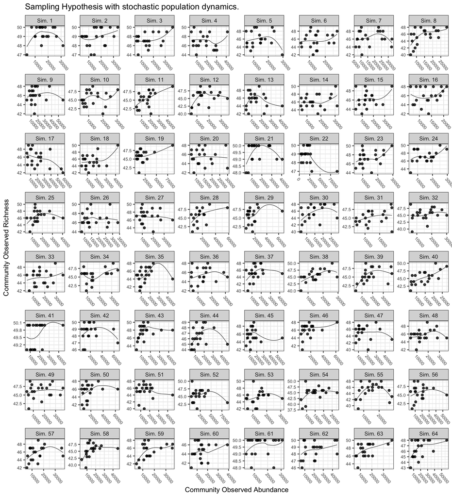

```r
# visualize
ggplot(filter(comm.tbl, as.numeric(Simulation) < 65 & Year == 20),
       aes(x=N.tot, y=S, group=Sim)) +
  facet_wrap(~Sim, scales="free") + geom_point(alpha=0.8) +
  stat_smooth(colour="black", se=FALSE, size=0.25, method="loess", span=1.1) +
  labs(x="Community Observed Abundance", y="Community Observed Richness") +
  ggtitle("Sampling Hypothesis with stochastic population dynamics.") +
  theme(axis.text.x=element_text(angle=310, hjust=0),
        axis.text=element_text(size=7))
```

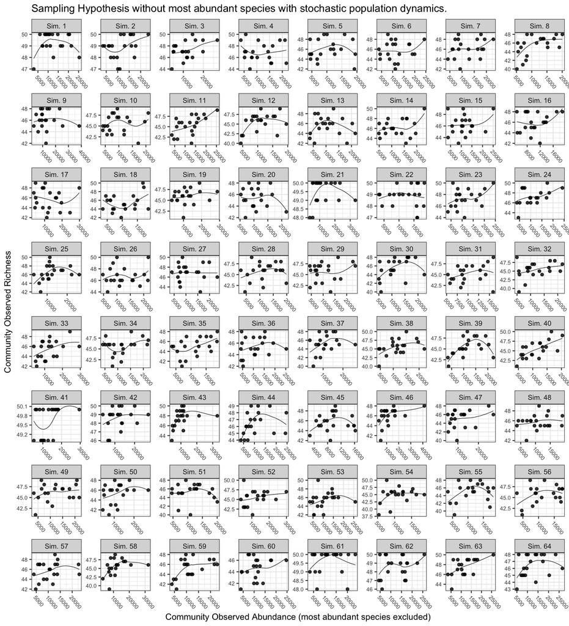

```r
ggplot(filter(comm.tbl, as.numeric(Simulation) < 65 & Year == 20),
       aes(x=N.noDom, y=S, group=Sim)) +
  facet_wrap(~Sim, scales="free") + geom_point(alpha=0.8) +
  stat_smooth(colour="black", se=FALSE, size=0.25, method="loess", span=1.1) +
  labs(x="Community Observed Abundance (most abundant species excluded)", y="Community Observed Richness") +
  ggtitle("Sampling Hypothesis without most abundant species with stochastic population dynamics.") +
  theme(axis.text.x=element_text(angle=310, hjust=0),
        axis.text=element_text(size=7))
```

## Increased population size

#### Overview

Areas with more productive energy can support more individuals, allowing species to obtain higher population sizes that reduce extinction rates and elevate species richness.

**NPP –> abundance –> lower extinction –> more species**

#### Text

The increased population size mechanism assumes that additional energy enables most species to increase their abundance, and is central to Wright’s (1983) derivation of species–energy theory from the species-area relationship. Species richness may increase with area because larger areas contain more resources and support more individuals, enabling species to obtain higher population sizes that reduce their extinction risk (Preston, 1962; MacArthur & Wilson, 1963, 1967). Energy availability may be a better measure of resource abundance than area, and species–energy theory is obtained essentially by replacing ‘area’ with ‘energy availability’ in the species-area relationship (Wright, 1983). The thermoregulatory load theory (Turner et al., 1988), that in high-energy areas individuals can divert resources from thermoregulation to activities such as reproduction, may also contribute to elevated abundance and thus species richness in high-energy areas.

#### Scale & taxonomy

The increased population size mechanism assumes that additional energy increases resource abundance sufficiently to increase population size and reduce extinction risk. As spatial grain increases, a given proportional increase in energy availability will produce a greater total increase in resource abundance, increasing the probability that population viability will be increased sufficiently. The increased population size mechanism may thus be more applicable at larger spatial grains. Population size and extinction risk are, however, related by a negative decelerating function (Leigh, 1981; Pimm, Jones & Diamond, 1988; Lande, 1993) and at large spatial grains population sizes may be sufficiently large that further increases have a negligible impact on extinction risk and thus species richness. The increased population size mechanism may thus be most applicable at intermediate spatial scales.

The assumption that increasing energy availability will reduce extinction risk, by increasing population size, is less likely to be met in taxa with traits that buffer small populations from extinction. Such traits may include high dispersal ability, increasing the probability of colonisation rescuing populations from extinction, and reproductive methods (e.g. asexual) that increase potential reproductive rates at low densities, when finding a mate may be difficult.

#### Predictions

Given that extinction risk is a negative decelerating function of population size, the increased population size mechanism predicts that, when controlling for sampling effects (see section III.1), species richness is a positive decelerating function of total abundance and energy. Similar patterns may, however, occasionally arise through the dynamic equilibrium, niche position and more trophic levels mechanisms (see sections III.3, III.4 and III.6) and additional information is required to support the increased population size mechanism.

The influence of energy on extinction may be tested using time series of species lists whilst controlling for confounding factors, e.g. habitat change. In low-energy areas previous extinctions may have reduced the assemblage to extinction-resistant species. Thus analyses may need to be confined to species occurring in both high- and low-energy areas. The sampling mechanism does not predict that energy influences extinction risk and testing this may facilitate distinguishing between these mechanisms.

If relationships between population size and extinction risk are generally consistent across space then species may always acquire their minimum viable population sizes at a certain threshold of energy availability and thus be consistently present above, and consistently absent below, this threshold. If so, nested species distribution patterns may arise in which the species present in low-energy areas are a non-random subset of those in high-energy areas. Lack of sufficient knowledge on species distributions may, however, prevent conducting such tests for many taxa.

#### Summary

Theory and empirical data support the pathways and assumptions described by the increased population size mechanism, increasing the probability that it frequently contributes to species–energy relationships. However, it may not apply in all cases and few studies adequately distinguish between it and the sampling mechanism; claims that the former is the established cause of species–energy relationships (Rosenzweig & Abramsky, 1993) may thus be premature.

## Dynamic equilibrium

#### Overview

Increased productive energy enables populations to recover faster from disturbance, reducing the time-period during which they are vulnerable to extinction due to their small population size. In high-energy areas, extinction rates are reduced and thus species richness is increased.

**NPP –> faster post-disturbance recovery –> lower extinction –> more species**

#### Text

The dynamic equilibrium mechanism (Huston, 1979) argues that energy availability mediates the relationship between disturbance and species richness, i.e. the Intermediate Disturbance Hypothesis, IDH (Connell, 1978). The IDH states that disturbances alter species richness because they reduce population densities. Whether disturbances increase or decrease species richness depends on the magnitude of population decline and thus disturbance frequency and magnitude. Minor disturbances may not lower population sizes to the extent that extinction risk increases significantly, but population declines may be sufficient to reduce inter-specific competition and rates of competitive exclusion, elevating species richness. Major disturbances may cause population declines that increase extinction risk sufficiently to over-ride the effects of reduced competitive exclusion, thus decreasing species richness and generating a unimodal disturbance-richness relationship.

The dynamic equilibrium mechanism suggests that increased productive energy availability may increase recovery rates from disturbance and reduce the time period during which species are vulnerable to extinction due to small population sizes. Following a disturbance, per species extinction rates may thus be lower in high-energy areas, generating positive species–energy relationships (Huston, 1979, 1994; deAngelis, 1995). Very high levels of energy availability may increase population recovery rates sufficiently to generate large population sizes that cause competitive exclusion and reduce species richness, creating a unimodal species–energy relationship (Huston, 1979). In the rest of this section, however, we confine our discussion to whether the dynamic equilibrium mechanism generates positive species–energy relationships.

#### Scale & taxonomy

Testing the dynamic equilibrium mechanism requires the comparison of post-disturbance population growth rates; the need to control for disturbance severity in such comparisons requires data on disturbance histories. At a macro-scale, it may be hard to obtain simultaneous measurements of numerous disturbance phenomena at a single site and theoretically challenging to sum these into a composite measure, rendering it difficult to test the dynamic equilibrium mechanism at the macro-scale (Peterson & Parker, 1998; Whittaker, Willis & Field, 2001). If energy availability mediates disturbance effects, the latter must reduce population sizes sufficiently to increase extinction risk. As grain size increases, the magnitude of disturbance required to cause extinctions increases, and assuming that disturbance severity is negatively related to disturbance frequency the mechanism is unlikely to operate at the macro-scale.

Taxonomic groups may differ in their response to a particular environmental change ; disturbances may increase some populations, but decrease others. For example, forest fragmentation reduces soil-feeding termite abundance, but wood-feeding termites increase (Davies, 2002). Similarly, following agricultural intensification, some avian groups, such as buntings (Emberiza spp.), decline in abundance whilst others, such as corvids, increase (Siriwardena et al., 1998). The probability of the mechanism generating positive species–energy relationships may thus vary between taxonomic groups in a manner that depends on the nature of the disturbance event and the homogeneity of the taxonomic group’s response to disturbance.

#### Predictions

The diagnostic prediction of the dynamic equilibrium mechanism is that recovery rates from disturbance are positively correlated with energy. Three other patterns may arise from the dynamic equilibrium mechanism that may also be generated through other mechanisms. First, faster recovery rates in high-energy areas will reduce the period during which the small populations arising from disturbance are vulnerable to extinction, which could lead to observations of lower extinction rates in high-energy areas. Second, faster recovery rates in high-energy areas may generate higher population densities in such areas. Finally, species may have a minimum threshold of energy availability below which they cannot recover from disturbance and species may always be absent from localities where energy is below this threshold, generating nested species distributions.

#### Summary

The dynamic equilibrium mechanism has not been sufficiently tested. Doing so may be especially difficult at the macro-scale, at which it is uncertain if its assumptions will be met.

## Niche position

#### Overview

Increased productive energy increases the abundance of the relatively rare resources that are exploited by niche position specialists. In high-energy areas, more species of niche-position specialists can maintain viable populations, thus increasing species richness.

**NPP –> more rare resources –> more position specialists –> more species**

#### Text

Specialised species can be defined in two ways (Shugart & Patten, 1972). Niche position specialists use relatively rare resources and niche breadth specialists (see section III.5) use a narrow resource range. The two types of specialism need not be interchangeable (Gaston, 1994; Gregory & Gaston, 2000), and both may contribute to species–energy relationships.

In low-energy areas the abundance of relatively rare resources may not be sufficient to support viable populations of the niche position specialists that depend on them (Abrams, 1995). Additional energy may thus elevate the abundance of relatively rare resources and the population viability of niche position specialists, generating positive species–energy relationships. This mechanism argues that energy availability limits population size and could be classified as part of the increased population size mechanism. However, the two make sufficiently different predictions for their contributions to be distinguished and it is useful to treat them separately.

At high-energy levels more resource types may be able to support viable populations, increasing resource diversity, which is a major component of habitat heterogeneity. The latter is sometimes considered to be independent of energy availability and to rival it as an explanatory mechanism for species richness patterns (e.g. Williams, 1964; Kerr & Packer, 1997; Hurlbert & Haskell, 2003). However, the niche position mechanism provides a potential causal link between increased productive energy availability and increased habitat heterogeneity (Fig. 2). Whilst habitat diversity can influence species richness independently of energy (Kerr, Southwood & Cihlar, 2001), the niche position and habitat heterogeneity mechanisms may be viewed as potentially complementary and related explanations for spatial variation in species richness.

#### Scale & taxonomy

The niche position mechanism relies upon strong positive correlations between energy and abundance of niche position specialists. As spatial grain increases a given proportional increase in energy may result in a greater total increase in resource abundance and thus population size, increasing the niche position mechanism’s contribution to species–energy relationships. Some evidence for this comes from studies documenting stronger influences of habitat diversity, which may correlate with relatively rare resource abundance, at larger spatial grains (Fraser, 1998; Hurlbert & Haskell, 2003). It is more likely to apply to taxa rich in niche position specialists.

#### Predictions

The niche position mechanism closely resembles the increased population size mechanism and both predict that, when removing the effects of sampling, species richness, total abundance and energy availability will be positively correlated. The former’s key prediction, however, is that such responses will be disproportionately stronger in niche position specialists. The increased population size mechanism predicts that rare species will exhibit the strongest species–energy relationships (see section III.2). If rarity is predominantly a result of a high niche position, which is plausible but not a generality (Gaston, 1994), then the increased population size mechanism may also result in a disproportionate increase in species richness among niche position specialists. The niche position and increased population size mechanisms also share the subsidiary predictions that nested species distributions may arise and that extinction risk and energy availability are negatively correlated.

#### Summary

The niche position mechanism may contribute to species–energy relationships in some cases, but has not been sufficiently tested. Its role as a general driver of species–energy relationships may be limited as additional energy may not always increase the abundance of the relatively rare resources used by niche position specialists.

## Niche breadth

#### Overview

Increased productive energy elevates the abundance of individual resource types, enabling species to switch patterns of resource use away from less preferred resources. This reduced niche breadth leads to reduced niche overlap, reducing rates of competitive exclusion and thus elevating species richness in high-energy areas.

**NPP –> more of each resource –> narrower breadths –> less competition –> more species**

#### Text

Resource abundance may increase with productive energy availability. If favoured resource types increase in abundance, species may increase consumption of these resources and reduce use of less optimal resources, leading to reduced niche breadth in high-energy areas. Assuming that reduced niche-breadths generate reduced niche overlaps and lower rates of competitive exclusion, co-existence may be promoted in high-energy areas causing positive species–energy relationships.

#### Scale & taxonomy

The niche breadth mechanism assumes that assemblages are structured by competitive exclusion; this may be less likely at the large spatial scales that promote co-existence of competing species through spatial segregation. As spatial extent increases, assemblages in different localities are more likely to be derived from different regional species pools. Factors influencing the size of these pools may constrain the effects of locally operating factors, such as competition, on species richness (Cornell, 1999). Indeed, all mechanisms that generate species–energy relationships through inter-specific interactions may only apply at small spatial grains (Whittaker et al., 2001).

#### Predictions

The niche breadth mechanism diagnostically predicts that niche breadths will be wider in low-energy areas. Assuming that weaker competitors have not yet become extinct, niche overlaps may also be greater in such areas. The niche breadth mechanism shares two predictions with other mechanisms. First, if assemblages are sampled before weak competitors become extinct, competitive exclusion, and thus extinction, rates may be higher in low-energy areas. Second, the niche breadth mechanism may generate nested species distribution patterns. Two competing species may co-exist only when energy is sufficiently high to enable them to exploit different resources and avoid competitive exclusion. When energy availability falls below this critical threshold one species will become locally extinct. If stochastic factors, such as initial population densities, do not influence the outcome of competition the identity of this species will be consistent. Weak competitors may thus only occur in localities where energy availability is above the critical threshold at which they avoid competition, generating nested species distributions in which the species present in low-energy areas are a non-random subset, superior competitors, of those in high-energy areas.

#### Summary

Increased energy availability is unlikely to generate permanent and consistent reductions in niche breadths and overlaps; equally plausible outcomes have been observed or hypothesised. The mechanism assumes that competition structures assemblages, which is less likely at large spatial grains. It is thus unlikely to promote frequently macro-scale species–energy relationships.

## More trophic levels

#### Overview

Productive energy availability limits the number of trophic levels. Increasing energy availability allows additional trophic levels to occur that are occupied by novel consumer species, thus leading to higher species richness in high-energy areas.

**NPP –> broader pyramid base –> more consumer species –> more species**

#### Text

The energy efficiency of consumers is generally very low and the energy available in a trophic level declines with its height (Pimm, 1982). Eventually, a trophic level may contain insufficient energy to support additional ones. The number of trophic levels in a system may thus depend on energy received by the base trophic level; additional energy may enable extra trophic levels to arise, which support novel consumer species, generating positive species–energy relationships (Oksanen et al., 1981; Fretwell, 1987; Schoener, 1990; Kaunzinger & Morin, 1998).

#### Scale & taxonomy

Reducing spatial grain reduces the probability that a given proportional increase in energy is sufficient to support additional trophic levels. At large spatial grains high trophic levels are more likely to be present, reducing the probability that new ones can be added. The mechanism may thus be most applicable at intermediate spatial grains. It cannot apply to taxa restricted to the base trophic level, such as non-carnivorous green plants, and is less likely to apply to omnivores, relative to species occupying single trophic levels, as the number of trophic levels is less likely to influence their occurrence.

#### Predictions

The mechanism’s diagnostic prediction is that, when controlling for sampling effects, the number of trophic levels is positively correlated with productive energy availability and species richness. It may also generate two patterns that could arise through other mechanisms. First, nested species distribution patterns may arise if the novel species that invade additional trophic levels cannot occupy lower trophic levels, and thus do not occur in low-energy areas. Second, the presence of additional trophic levels in high-energy areas may generate positive correlations between energy availability and total abundance in an assemblage, assuming that increased consumption does not reduce abundance in lower trophic levels.

#### Summary

Energy appears to limit the number of trophic levels only rarely, significantly reducing the likelihood that the more trophic levels mechanism generally promotes species–energy relationships.

## Consumer pressure

#### Overview

As a consequence of the other mechanisms described, consumers are more abundant and/or diverse in high-energy areas. These increases lead to greater reductions in prey populations, which reduce the strength of inter-specific competition and promote co-existence of prey species, generating elevated species richness in high-energy areas.

**NPP –> consumer abundance –> lower prey abundance –> reduced prey competition –> more species**

#### Text

Consumer abundance and species richness may, in theory, increase with energy through the other mechanisms that we describe. These increases may elevate consumer pressure, the ability of consumers to reduce prey populations. Lower prey densities in high-energy areas may reduce rates of competitive exclusion and generate positive species–energy relationships. Paine (1966) advanced the concept that predation may influence species richness; others have expanded his theory to include any form of ‘top-down’ regulation (e.g. Janzen, 1970; Abrams, 1983, 1995). Consumer pressure may increase with energy sufficiently to generate a unimodal species–energy relationship.

#### Scale & taxonomy

The mechanism relies on energy influencing competitive exclusion, which is less likely at the large spatial grains that promote co-existence through spatial segregation. As spatial extent increases, assemblages are more likely to be derived from different regional species pools, whose size variation may reduce competition’s influence on species richness (Cornell, 1999); the consumer pressure mechanism is thus less likely to generate macro-scale species–energy relationships. Functional groups confined to high trophic levels are probably exposed to low consumption rates and consumer pressure is less likely to influence their species richness.

#### Predictions

The consumer pressure mechanism’s diagnostic prediction is that high-energy availability increases consumption rates, per unit of resource biomass, lowering prey population densities, relative to the carrying capacity. It shares two predictions with other mechanisms. First, it argues that competitive exclusion rates are lower in high-energy areas; therefore, when competitive exclusion is still occurring, the per species extinction rate may be lower in high-energy areas (assuming that competitive exclusion is the dominant cause of extinction). Second, a pair of competing prey species may only co-exist when energy is above the threshold at which consumption rates are sufficiently high to reduce population densities below those at which competitive exclusion occurs. If the identity of the excluded species is constant, i.e. not influenced by stochastic factors such as initial relative densities, then competitively inferior species may only occur in areas whose high energy levels enable them to avoid competitive exclusion, generating nested species distributions.

#### Summary

Top-down forces can strongly influence assemblage struc- ture, the strength of inter-specific competition and thus species richness. Their strength, however, seems unlikely to be mediated by energy and high consumer pressure may reduce richness. Consumer pressure is thus probably not a general promoter of species–energy relationships, particularly at macro-scales, where spatial segregation may reduce the influence of competition on species richness.

## Range limitation

#### Overview

As solar energy increases, climatic conditions are within the physiological tolerance range of more species, resulting in higher species richness.

**NPP=temp –> climate within more physiological limits –> more species**

#### Text

Von Humboldt (1808) proposed that few species occur at the poles because most cannot withstand freezing. The range limitation mechanism expands his idea and argues that more species can physiologically tolerate climatic conditions in high-energy areas than low-energy ones, enabling more species to occur in the former (Kerr et al., 1998).

#### Scale & taxonomy

At very small spatial grains species richness is more likely to be constrained by other factors, such as area or historical effects, than by the number of physiologically adapted species (Gaston, 2003). Factors limiting species ranges may be scale dependent. As spatial extent increases, dispersal barriers are more likely to be encountered and may replace climate as the limitation on distributions (Gaston, 2003). The range limitation mechanism is thus less likely to influence species richness at both very small spatial grains and large extents, limiting its contribution to macro-scale species–energy relationships.

#### Predictions

The range limitation mechanism’s primary prediction is that species always occur in areas where they can meet their physiological requirements. Nested species distributions should thus arise in which the species in areas with low-energy availability have a broader range of climatic tolerances than the species in high-energy areas.

#### Summary

More species can probably tolerate climatic conditions in high-energy areas than low-energy ones, except at extremely high energy levels. Climate can influence species’ distributional limits, but is frequently unlikely to be the dominant limiting factor, particularly at the macro-scale. The mechanism also only offers a proximate explanation; why are more species adapted to high-energy areas? The diversification rate mechanism, an additional potential driver of species–energy relationships, may offer a solution.

## Diversification rate

#### Overview

Global species richness is the sum of speciation events minus extinction events, and these variables may influence richness at smaller spatial scales. Increased availability of solar and/or productive energy generates faster speciation rates and/or lower extinction rates, promoting species-energy relationships.

**NPP/temp –> higher speciation rates or lower extinction rates –> more species**

#### Text

Current global species richness is the sum of speciation events minus the sum of global extinction events. Spatial variation in these events may be influenced by energy, contributing to species–energy relationships. Rohde (1978, 1992) expanded earlier suggestions that high-energy levels may increase speciation rates (Wallace, 1878). Relationships between speciation/extinction rates and energy may arise directly through the influence of solar energy on mutation rates, and most literature on the diversification rate mechanism focuses on this relationship. Alternatively, both solar and productive energy availability may influence speciation/extinction rates indirectly through variables such as body size and reproductive rates. The unified neutral theory also predicts that larger populations, which may occur in high-energy areas (see Section III.2), may promote faster evolutionary rates (Hubbell, 2001).

#### Scale & taxonomy

The diversification rate mechanism implies spatial variation in speciation/extinction rates. Both variables operate at the scale of geographical ranges and the mechanism may not apply to studies conducted at extents smaller than the average geographical range of the taxa considered. More pathways may influence the diversification rates of ectotherms than endotherms (see section III. 9.c) and the mechanism is thus more likely to contribute to species–energy relationships in the former.

#### Predictions

The diagnostic prediction of the diversification rate mechanism is that energy availability elevates diversification rates. This can be assessed, albeit crudely and indirectly, by comparing the species richness of sister clades, with more speciose clades predicted to have greater energy availability. It has been predicted that if high-energy availability promotes speciation, younger taxa will dominate high-energy assemblages (Stehli & Wells, 1971 ; McCoy & Heck, 1976 ; Rohde, 1992). Such predictions are, however, too simple. Lower extinction rates may increase evolutionary age in high-energy areas and low-energy ones may receive newly evolved taxa dispersing from high-energy areas (Gaston & Blackburn, 1996 ; Kerr & Currie, 1999).

Speciation rates should be closely and positively related to molecular evolution rates, which should thus increase with energy availability (Rohde, 1978, 1992; Bromham & Cardillo, 2003). Genetic distances of species pairs, measured relative to an outgroup, by either the relative rates test or DNA hybridisation distances, should thus be greater in species occupying high-energy areas (Li & Graur, 1991; Mooers & Harvey, 1994; Bromham & Cardillo, 2003).

Full assessment of the diversification rate mechanism requires data on both speciation and extinction rates, which the fossil record could provide – although appearances and disappearances may reflect distributional changes or gaps in the record, rather than speciation/extinction. Moreover, obtaining data on the energy available to fossilised species when they were living is difficult and current energy levels may have to suffice.

#### Summary

The diversification rate mechanism incorporates many pathways that may link energy availability to speciation and extinction rates. Theory suggests that high solar and productive energy availability may reduce extinction rates, but the limited data do not support this. Increased solar radiation probably directly increases mutation and speciation rates, but whether productive energy does so indirectly, through factors such as body size is unclear. The one explicit test of the diversification rate mechanism (Cardillo, 1999) provides some support for it. Many more tests that simultaneously combine information on speciation and extinction rates are needed before the mechanism’s contribution can be assessed fully.

# Confounding variables

## Area

## Seasonality

## Long-term stability